# Assignment 8

## Setup

```r
knitr::opts_chunk$set(echo = TRUE, comment = "#>", dpi = 300)

for (f in list.files(here::here("src"), pattern = "R$", full.names = TRUE)) {
  source(f)
}

library(rstan)
library(bayestestR)
library(loo)
library(tidybayes)
library(tidyverse)

rstan_options(auto_write = TRUE)
options(mc.cores = 2)

theme_set(theme_classic() + theme(strip.background = element_blank()))

factory <- aaltobda::factory
set.seed(678)
```

**Assignment 8**

## Exercise 1. Model assessment: LOO-CV for factory data with Stan

**Use leave-one-out cross-validation (LOO-CV) to assess the predictive performance of the pooled, separate and hierarchical Gaussian models for the factory dataset (see the second exercise in Assignment 7).**

**a) Fit the models with Stan as instructed in Assignment 7.** **To use the `loo` or `psisloo` functions, you need to compute the log-likelihood values of each observation for every posterior draw (i.e. an $S$-by-$N$ matrix, where $S$ is the number of posterior draws and $N = 30$ is the total number of observations).** **This can be done in the `generated quantities` block in the Stan code; for a demonstration, see the Gaussian linear model `lin.stan` in the R Stan examples that can be found here.**

*Separate model*

```r
separate_model_code <- here::here(
  "models", "assignment07_factories_separate.stan"
)

separate_model_data <- list(
  y = factory,
  N = nrow(factory),
  J = ncol(factory)
)

separate_model <- rstan::stan(
  separate_model_code,
  data = separate_model_data,
  verbose = FALSE,
  refresh = 0
)

print(separate_model, pars = c("mu", "sigma"))
```

```
#> Inference for Stan model: assignment07_factories_separate.
#> 4 chains, each with iter=2000; warmup=1000; thin=1;
#> post-warmup draws per chain=1000, total post-warmup draws=4000.
#>
#>            mean se_mean   sd   2.5%    25%    50%    75%  97.5% n_eff
#> mu[1]     85.74    0.13 7.30  72.77  80.60  85.40  90.50 101.41  2985
#> mu[2]    105.07    0.07 4.40  96.26 102.25 105.16 107.86 113.48  3528
#> mu[3]     90.40    0.08 4.62  81.81  87.40  90.12  93.23 100.44  3546
#> mu[4]    110.56    0.06 3.12 104.01 108.86 110.67 112.45 116.16  2523
#> mu[5]     91.46    0.06 3.90  84.00  89.00  91.29  93.83  99.79  3928
#> mu[6]     91.25    0.11 6.31  79.88  87.09  90.80  94.99 104.94  3392
#> sigma[1]  19.28    0.14 6.92  10.51  14.54  17.85  22.36  36.47  2495
#> sigma[2]  10.41    0.06 3.32   6.14   8.14   9.78  11.92  18.78  2971
#> sigma[3]  11.42    0.07 3.76   6.62   8.86  10.57  13.13  20.71  2825
#> sigma[4]   6.85    0.06 2.47   3.90   5.26   6.37   7.82  12.71  1640
#>          Rhat
#> mu[1]       1
#> mu[2]       1
#> mu[3]       1
#> mu[4]       1
#> mu[5]       1
#> mu[6]       1
#> sigma[1]    1
#> sigma[2]    1
#> sigma[3]    1
#> sigma[4]    1
#>  [ reached getOption("max.print") -- omitted 2 rows ]
#>
#> Samples were drawn using NUTS(diag_e) at Mon Nov 15 06:50:05 2021.
#> For each parameter, n_eff is a crude measure of effective sample size,
#> and Rhat is the potential scale reduction factor on split chains (at
#> convergence, Rhat=1).
```

*Pooled model*

```r
pooled_model_code <- here::here("models", "assignment07_factories_pooled.stan")

pooled_model_data <- list(
  y = unname(unlist(factory)),
  N = length(unlist(factory))
)

pooled_model <- rstan::stan(
  pooled_model_code,
  data = pooled_model_data,
  verbose = FALSE,
  refresh = 0
)

print(pooled_model, pars = c("mu", "sigma"))
```

```
#> Inference for Stan model: assignment07_factories_pooled.
#> 4 chains, each with iter=2000; warmup=1000; thin=1;
#> post-warmup draws per chain=1000, total post-warmup draws=4000.
#>
#>        mean se_mean   sd  2.5%   25%   50%   75% 97.5% n_eff Rhat
#> mu    93.64    0.06 3.15 87.50 91.56 93.62 95.67 99.94  2906    1
#> sigma 17.74    0.04 2.33 13.92 16.06 17.47 19.16 22.88  2707    1
#>
#> Samples were drawn using NUTS(diag_e) at Mon Nov 15 06:50:08 2021.
#> For each parameter, n_eff is a crude measure of effective sample size,
#> and Rhat is the potential scale reduction factor on split chains (at
#> convergence, Rhat=1).
```

*Hierarchical model*

```r
hierarchical_model_code <- here::here(
  "models", "assignment07_factories_hierarchical.stan"
)

hierarchical_model_data <- list(
  y = factory,
  N = nrow(factory),
  J = ncol(factory)
)

hierarchical_model <- rstan::stan(
  hierarchical_model_code,
  data = hierarchical_model_data,
  verbose = FALSE,
  refresh = 0
)

print(hierarchical_model, pars = c("alpha", "tau", "mu", "sigma"))
```

```
#> Inference for Stan model: assignment07_factories_hierarchical.
#> 4 chains, each with iter=2000; warmup=1000; thin=1;
#> post-warmup draws per chain=1000, total post-warmup draws=4000.
#>
#>         mean se_mean   sd  2.5%    25%    50%    75%  97.5% n_eff
#> alpha  94.41    0.10 4.78 85.24  91.39  94.29  97.40 104.17  2494
#> tau    11.05    0.10 4.10  3.95   8.22  10.69  13.47  20.31  1553
#> mu[1]  81.44    0.14 6.49 68.80  77.10  81.38  85.74  94.34  2149
#> mu[2] 102.57    0.12 5.95 90.92  98.53 102.69 106.61 114.11  2284
#> mu[3]  89.67    0.09 5.64 78.42  85.93  89.81  93.40 100.81  3766
#> mu[4] 106.30    0.14 6.45 93.74 102.05 106.43 110.81 118.65  2019
#> mu[5]  91.15    0.09 5.64 79.59  87.50  91.11  94.99 102.27  3658
#> mu[6]  88.49    0.11 5.74 77.40  84.49  88.53  92.40  99.48  2893
#> sigma  14.34    0.05 2.11 10.93  12.83  14.10  15.57  19.13  2008
#>       Rhat
#> alpha    1
#> tau      1
#> mu[1]    1
#> mu[2]    1
#> mu[3]    1
#> mu[4]    1
#> mu[5]    1
#> mu[6]    1
#> sigma    1
#>
#> Samples were drawn using NUTS(diag_e) at Mon Nov 15 06:50:11 2021.
#> For each parameter, n_eff is a crude measure of effective sample size,
#> and Rhat is the potential scale reduction factor on split chains (at
#> convergence, Rhat=1).
```

**b) Compute the PSIS-LOO elpd values and the $\hat{k}$-values for each of the three models.** **Hint! It will be convenient to visualize the $\hat{k}$-values for each model so that you can easily see how many of these values fall in the range $\hat{k} > 0.7$ to assess the reliability of the PSIS-LOO estimate for each model.** **You can read more about the theoretical guarantees for the accuracy of the estimate depending on $\hat{k}$ from the original article (see here or here), but regarding this assignment, it suffices to understand that if all the $\hat{k}$-values are $\hat{k} \le 0.7$, the PSIS-LOO estimate can be considered to be reliable, otherwise there is a concern that it may be biased (too optimistic, overestimating the predictive accuracy of the model).**

```r
calc_loo <- function(mdl) {
  log_lik <- loo::extract_log_lik(mdl, merge_chains = FALSE)
  r_eff <- loo::relative_eff(exp(log_lik))
  loo_res <- loo::loo(log_lik, r_eff = r_eff)
  return(loo_res)
}
```

*Separate model*

```r
separate_loo <- calc_loo(separate_model)
print(separate_loo)
```

```
#>
#> Computed from 4000 by 30 log-likelihood matrix
#>
#>          Estimate   SE
#> elpd_loo   -131.7  7.1
#> p_loo        13.6  3.5
#> looic       263.5 14.2
#> ------
#> Monte Carlo SE of elpd_loo is NA.
#>
#> Pareto k diagnostic values:
#>                          Count Pct.    Min. n_eff
#> (-Inf, 0.5]   (good)     19    63.3%   1810
#>  (0.5, 0.7]   (ok)        6    20.0%   572
#>    (0.7, 1]   (bad)       4    13.3%   32
#>    (1, Inf)   (very bad)  1     3.3%   12
#> See help('pareto-k-diagnostic') for details.
```

*Pooled model*

```r
pooled_loo <- calc_loo(pooled_model)
print(pooled_loo)
```

```
#>
#> Computed from 4000 by 30 log-likelihood matrix
#>
#>          Estimate  SE
#> elpd_loo   -130.9 4.9
#> p_loo         2.1 0.9
#> looic       261.9 9.7
#> ------
#> Monte Carlo SE of elpd_loo is 0.0.
#>
#> All Pareto k estimates are good (k < 0.5).
#> See help('pareto-k-diagnostic') for details.
```

*Hierarchical model*

```r
hierarchical_loo <- calc_loo(hierarchical_model)
print(hierarchical_loo)
```

```
#>
#> Computed from 4000 by 30 log-likelihood matrix
#>
#>          Estimate   SE
#> elpd_loo   -127.2  5.0
#> p_loo         6.3  1.8
#> looic       254.3 10.0
#> ------
#> Monte Carlo SE of elpd_loo is 0.1.
#>
#> Pareto k diagnostic values:
#>                          Count Pct.    Min. n_eff
#> (-Inf, 0.5]   (good)     28    93.3%   1407
#>  (0.5, 0.7]   (ok)        2     6.7%   173
#>    (0.7, 1]   (bad)       0     0.0%   <NA>
#>    (1, Inf)   (very bad)  0     0.0%   <NA>
#>
#> All Pareto k estimates are ok (k < 0.7).
#> See help('pareto-k-diagnostic') for details.
```

```r
extract_p_eff <- function(loo_res) {
  loo_res$estimates[2, ]
}

bind_rows(
  extract_p_eff(separate_loo),
  extract_p_eff(pooled_loo),
  extract_p_eff(hierarchical_loo)
) %>%
  add_column(model = c("separate", "pooled", "hierarchical"))
```

```
#> # A tibble: 3 × 3
#>   Estimate    SE model
#>      <dbl> <dbl> <chr>
#> 1    13.6  3.47  separate
#> 2     2.13 0.892 pooled
#> 3     6.26 1.79  hierarchical
```

**d) Assess how reliable the PSIS-LOO estimates are for the three models based on the $\hat{k}$-values.**

```r
plot_khat <- function(loo_res, factory_data) {
  khat <- as.data.frame(loo_res$pointwise)$influence_pareto_k
  factory_data %>%
    mutate(idx = row_number()) %>%
    pivot_longer(-idx, names_to = "factory", values_to = "measure") %>%
    arrange(factory) %>%
    mutate(
      khat = !!khat,
      factory = str_replace(factory, "V", "factory ")
    ) %>%
    ggplot(aes(x = factor(idx), y = khat)) +
    facet_wrap(vars(factory), nrow = 1, scales = "free_x") +
    geom_hline(yintercept = c(0, 0.5, 0.7, 1.0), linetype = 2, color = "grey50") +
    geom_point(shape = 3, color = "#6497B1") +
    theme(axis.ticks = element_blank(), panel.grid.major.y = element_line()) +
    labs(x = "measurement", y = "Pareto shape k")
}
```

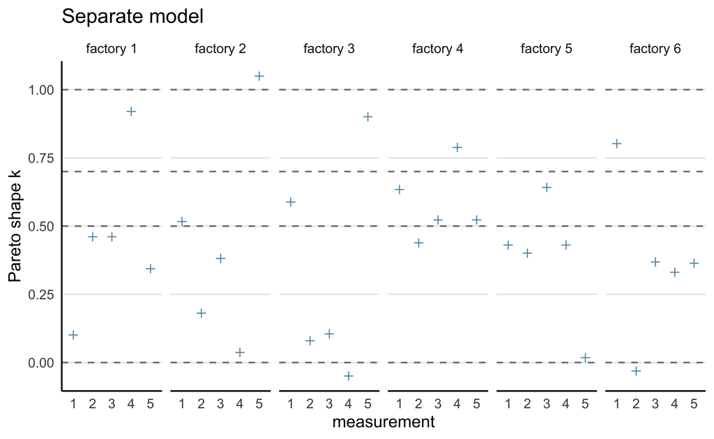

```r
plot_khat(separate_loo, factory) + labs(title="Separate model")
```

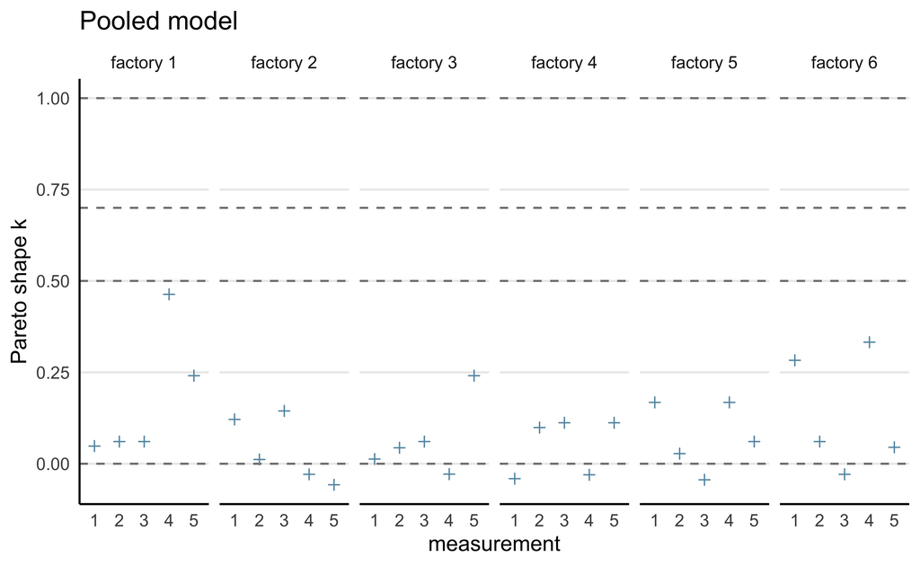

```r
plot_khat(pooled_loo, factory) + labs(title="Pooled model")
```

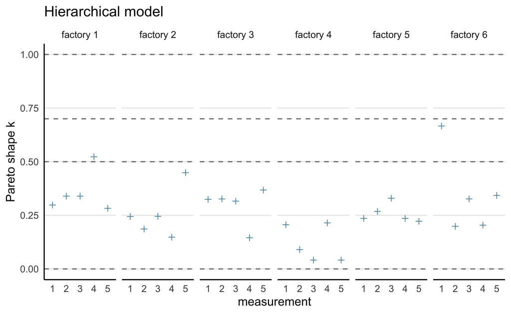

```r
plot_khat(hierarchical_loo, factory) + labs(title="Hierarchical model")
```

**e) An assessment of whether there are differences between the models with regard to the elpdloo-cv, and if so, which model should be selected according to PSIS-LOO.**

```r
extract_elpd <- function(loo_res) {
  loo_res$estimates[1, ]
}
```

```r
bind_rows(
  extract_elpd(separate_loo),
  extract_elpd(pooled_loo),
  extract_elpd(hierarchical_loo)
) %>%
  add_column(model = c("separate", "pooled", "hierarchical"))
```

```
#> # A tibble: 3 × 3
#>   Estimate    SE model
#>      <dbl> <dbl> <chr>
#> 1    -132.  7.08 separate
#> 2    -131.  4.86 pooled
#> 3    -127.  5.02 hierarchical
```

From the ELPD and $\hat{k}$ values, the hierarchical model is superior to the seaprate and pooled models.

**f) Both the Stan and R code should be included in your report.**